# US Mass Shootings Data Analysis

This tiny dataset which has around 300 rows contains information about Mass shootings carried out in united states. This dataset is obtained from the website Kaggle.

## 1. Loading The Dataset

```r
library(ggplot2)
library(scales)
library(tidyr)
library(dplyr)
library(formattable)
setwd("E:/MOOC")
shootings <- read.csv("MassShootingsDataset.csv",stringsAsFactors=FALSE)
```

## 2. Dimensions Of The Dataset

```r
dim(shootings)
```

```
[1] 320  13
```

## 3. Description of the variables and thier types.

```r
str(shootings)
```

```
'data.frame':   320 obs. of  13 variables:
 $ S.                  : int  1 2 3 4 5 6 7 8 9 10 ...
 $ Title               : chr  "Las Vegas Strip mass shooting" "San Francisco UPS shooting" "Pennsylvania supermarket shooting" "Florida awning manufacturer shooting" ...
 $ Location            : chr  "Las Vegas, NV" "San Francisco, CA" "Tunkhannock, PA" "Orlando, Florida" ...
 $ Date                : chr  "10/1/2017" "6/14/2017" "6/7/2017" "6/5/2017" ...
 $ Summary             : chr  "" "Jimmy Lam, 38, fatally shot three coworkers and wounded two others inside a UPS facility in San Francisco. Lam "| __truncated__ "Randy Stair, a 24-year-old worker at Weis grocery fatally shot three of his fellow employees. He reportedly fir"| __truncated__ "John Rob…
 $ Fatalities          : int  58 3 3 5 3 3 5 5 3 5 ...
 $ Injured             : int  527 2 0 0 0 0 6 0 3 11 ...
 $ Total.victims       : int  585 5 3 5 3 3 11 5 6 16 ...
 $ Mental.Health.Issues: chr  "Unclear" "Yes" "Unclear" "Unclear" ...
 $ Race                : chr  "White" "Asian" "White" "" ...
 $ Gender              : chr  "M" "M" "M" "M" ...
 $ Latitude            : num  36.2 NA NA NA NA ...
 $ Longitude           : num  -115 NA NA NA NA ...
```

## 4. Overall Metrics

```r
total_casualties <- sum(shootings$Fatalities)
total_injured <- sum(shootings$Injured)
total_victims <- sum(shootings$Total.victims)
sprintf("Total Number Of Casualties Reported Till Date: %s",total_casualties)
```

```
[1] "Total Number Of Casualties Reported Till Date: 1400"
```

```r
sprintf("Total Number Of Injured Reported Till Date: %s",total_injured)
```

```
[1] "Total Number Of Injured Reported Till Date: 1972"
```

```r
sprintf("Total Number Of Victims Reported Till Date: %s",total_victims)
```

```
[1] "Total Number Of Victims Reported Till Date: 3260"
```

## 5. Top 10 Mass Shootings

```r
shootings$Date <- as.Date(shootings$Date,"%m/%d/%Y")
shootings$Year <- format(shootings$Date,"%Y")
newData <- head(shootings[order(-shootings$Total.victims),],10)
row.names(newData) <- NULL
formattable(subset(newData, select = c(Title,Location,Total.victims,Year)),row.names = FALSE)
```

| Title | Location | Total.victims | Year |
| --- | --- | --- | --- |
| Las Vegas Strip mass shooting | Las Vegas, NV | 585 | 2017 |
| Orlando nightclub massacre | Orlando, Florida | 102 | 2016 |
| Aurora theater shooting | Aurora, Colorado | 82 | 2012 |
| Virginia Tech massacre | Blacksburg, Virginia | 55 | 2007 |
| University of Texas at Austin | Austin, Texas | 48 | 1966 |
| Fort Hood Army Base | Fort Hood, Texas | 45 | 2009 |
| Luby's Cafeteria in Killeen, Texas | Killeen, Texas | 43 | 1991 |
| McDonald's restaurant in San Ysidro | San Ysidro, California | 40 | 1984 |
| Columbine High School | Littleton, Colorado | 37 | 1999 |
| San Bernardino mass shooting | San Bernardino, California | 35 | 2015 |

## 6. Timeline Analysis

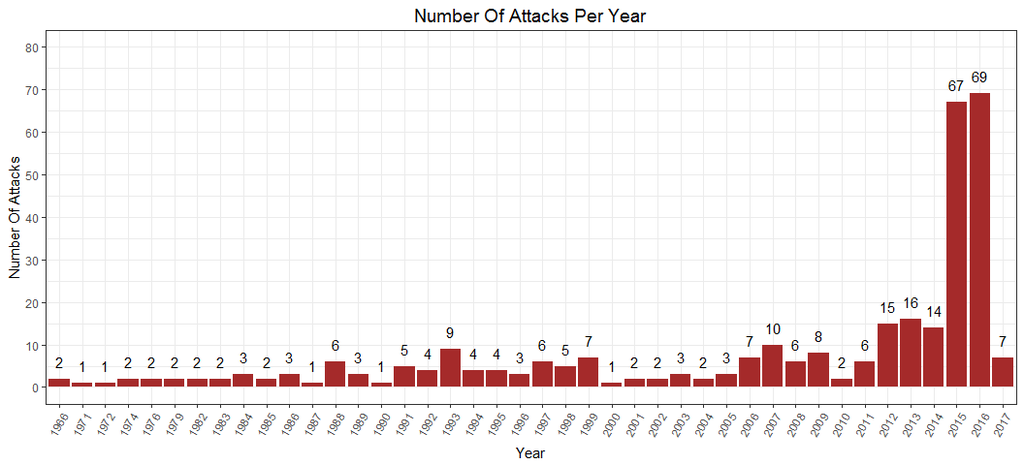

```r
ggplot(shootings,aes(x=Year))+
  geom_bar(fill="#A52A2A")+
  geom_text(stat='count',aes(label=..count..),vjust=-1)+
  scale_y_continuous(breaks = seq(0,80,10),limits = c(0,80))+
  labs(x="Year",y="Number Of Attacks",title="Number Of Attacks Per Year")+
  theme_bw()+
  theme(axis.text.x = element_text(angle = 60, hjust = 1))+
  theme(plot.title = element_text(hjust = 0.5,size = 14))+
  ggsave(filename = "outputs/fig-1.png",width = 11,height = 5)
```

- The above timeline analysis shows that highest number of attacks were carried out in the year 2015 and 2016, Now lets compare total.victims over a year timeline to see whether year 2015 and 2016 report high casualties too.

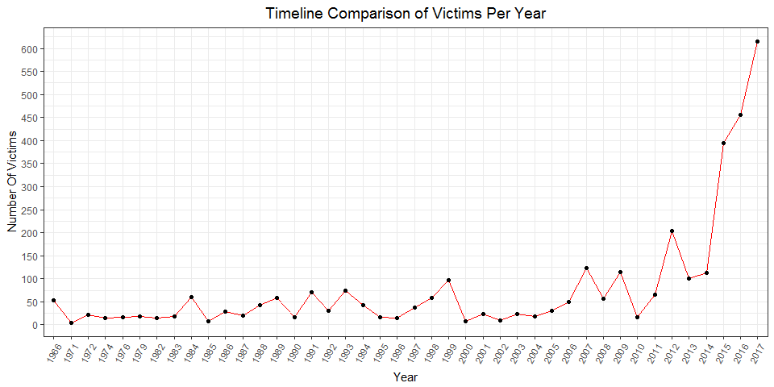

```r
ggplot(shootings,aes(x=Year,group=1))+
  geom_line(stat="summary",fun.y = sum,aes(y=Total.victims),color= "red")+
  geom_point(stat="summary",fun.y = sum,aes(y=Total.victims))+
  scale_y_continuous(breaks = seq(0,700,50))+
  labs(x="Year",y="Number Of Victims",title="Timeline Comparison of Victims Per Year")+
  theme_bw()+
  theme(axis.text.x = element_text(hjust = 1,angle = 60))+
  theme(plot.title = element_text(hjust = 0.5,size = 14))+
  ggsave(filename = "outputs/fig-2.png",width = 10,height = 5)
```

- As expected, very high number of victims were reported in year 2015 and 2016, but 2017 inspite of having very less attacks number of attacks, reported the highest number of victims because of “Las Vegas Strip mass shooting” in which around 526 people were injured and 58 people were killed. Now lets compare the total casualties over a year timeline.

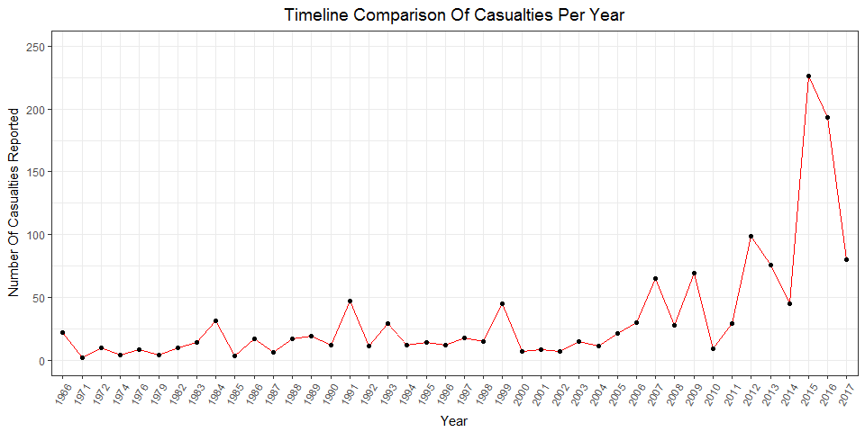

```r
ggplot(shootings,aes(x=Year,group=1))+
  geom_line(stat="summary",fun.y=sum,aes(y=Fatalities),color="red",size=0.5)+
  geom_point(stat="summary",fun.y=sum,aes(y=Fatalities))+
  labs(x="Year",y="Number Of Casualties Reported",title="Timeline Comparison Of Casualties Per Year")+
  scale_y_continuous(breaks = seq(0,350,50),limits = c(0,250))+
  theme_bw()+
  theme(axis.text.x = element_text(angle = 60,hjust = 1))+
  theme(plot.title = element_text(size = 14,hjust = 0.5))+
  ggsave(filename = "outputs/fig-3.png",width = 10,height = 5)
```

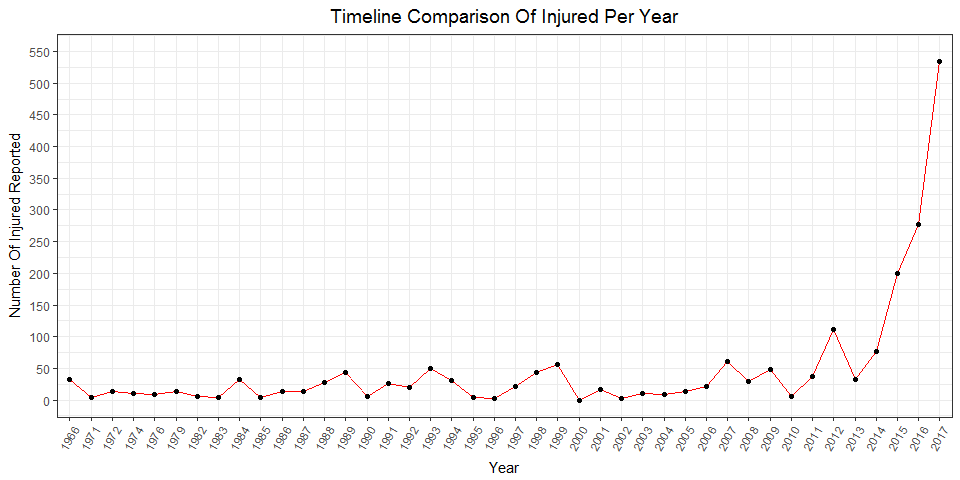

```r
ggplot(shootings,aes(x=Year,group=1))+
  geom_line(stat="summary",fun.y=sum,aes(y=Injured),color="red",size=0.5)+
  geom_point(stat="summary",fun.y=sum,aes(y=Injured))+
  labs(x="Year",y="Number Of Injured Reported",title="Timeline Comparison Of Injured Per Year")+
  scale_y_continuous(breaks = seq(0,550,50),limits = c(0,550))+
  theme_bw()+
  theme(axis.text.x = element_text(angle = 60,hjust = 1))+
  theme(plot.title = element_text(size = 14,hjust = 0.5))+
  ggsave(filename = "outputs/fig-4.png",width = 10,height = 5)
```

Lets combine the above metrics into a single graph which represents both the Fatalties and injured per year.

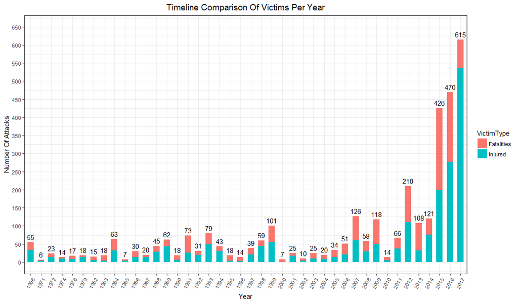

```r
long_data <- gather(subset(shootings,select = c(Year,Fatalities,Injured)),VictimType,NoOfVictims,Fatalities,Injured)
ggplot(long_data,aes(x=Year))+
  geom_bar(stat = "summary",fun.y=sum,aes(y=NoOfVictims,fill=VictimType),width = 0.6)+
  stat_summary(geom="text",fun.y=sum,aes(label=..y..,y=NoOfVictims),vjust = -0.5)+
  scale_y_continuous(breaks = seq(0,650,50),limits = c(0,650))+
  labs(x="Year",y="Number Of Attacks",title="Timeline Comparison Of Victims Per Year")+
  theme_bw()+
  #scale_fill_manual(values = c("red","blue"))+
  theme(axis.text.x = element_text(angle = 60, hjust = 1))+
  theme(plot.title = element_text(hjust = 0.5,size = 14))+
  ggsave(filename = "outputs/fig-5.png",width = 12,height = 5)
```

## 7. Mental Health Issues Exploration.

- Lets take a look at the data to identify anamolies.

```r
table(shootings$Mental.Health.Issues)
```

```
     No Unclear unknown Unknown     Yes
     90      13       1     110     106
```

- The data seams to contain duplicates for “Unknown” value and as “Unknown” and “Unclear” mean the same, lets rename the column values such that they contain consistent values.

```r
shootings$Mental.Health.Issues <- ifelse(shootings$Mental.Health.Issues == "unknown" | shootings$Mental.Health.Issues == "Unclear","Unknown",shootings$Mental.Health.Issues)
table(shootings$Mental.Health.Issues)
```

```
     No Unknown     Yes
     90     124     106
```

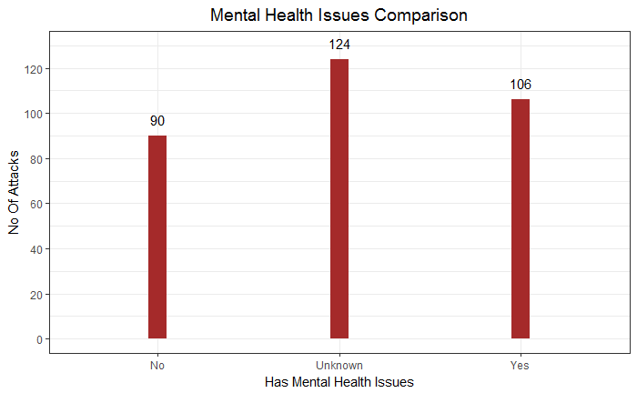

```r
ggplot(shootings,aes(x=Mental.Health.Issues))+
  geom_bar(width = 0.1,fill="#A52A2A")+
  geom_text(stat='count',aes(label=..count..),vjust=-1)+
  scale_y_continuous(limits = c(0,130),breaks = seq(0,130,20))+
  labs(x="Has Mental Health Issues",y="No Of Attacks",title = "Mental Health Issues Comparison")+
  theme_bw()+
  theme(plot.title = element_text(hjust = 0.5,size = 14))+
  ggsave(filename = "outputs/fig-6.png",width = 5,height = 5)
```

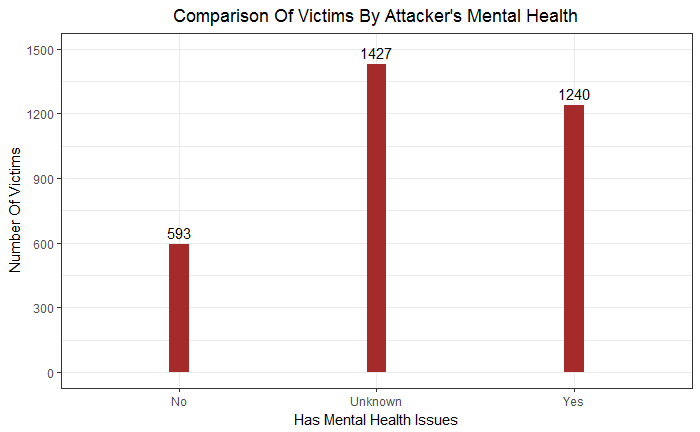

```r
ggplot(shootings,aes(x=Mental.Health.Issues,y=Total.victims))+
  geom_bar(stat="summary",fun.y=sum,width = 0.1,fill="#A52A2A")+
  stat_summary(aes(label=..y..), fun.y=sum, geom="text",vjust = -0.5)+
  labs(x="Has Mental Health Issues",y="Number Of Victims",title="Comparison Of Victims By Attacker's Mental Health")+
  scale_y_continuous(limits = c(0,1500),breaks = seq(0,1500,300))+
  theme_bw()+
  theme(plot.title = element_text(hjust = 0.5))+
  ggsave(filename = "outputs/fig-7.png",width = 5,height = 5)
```

## 8. Gender Based Exploration.

```r
table(shootings$Gender)
```

```
     Female           M         M/F        Male Male/Female     Unknown
          5          17           1         272           4          21
```

- The Gender data seems to contain few duplicates, Lets elminate these duplicates, so that data represents consistent values.

```r
shootings$Gender <- ifelse(shootings$Gender == "M","Male",ifelse(shootings$Gender == "M/F","Male/Female",shootings$Gender))
table(shootings$Gender)
```

```
     Female        Male Male/Female     Unknown
          5         289           5          21
```

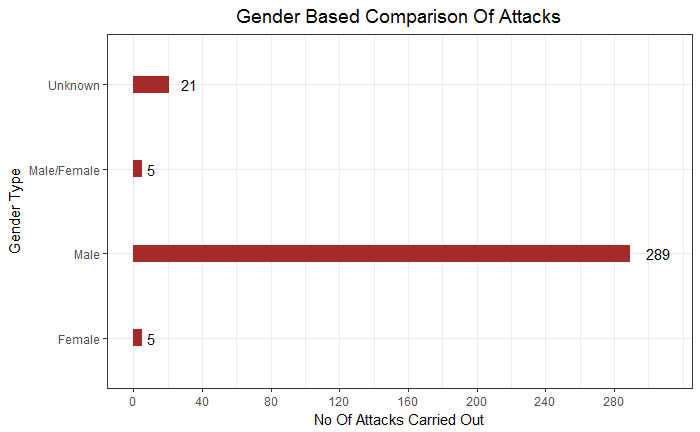

```r
ggplot(shootings,aes(x=Gender))+
  geom_bar(width = 0.2,fill="#A52A2A")+
  geom_text(stat='count',aes(label=..count..),hjust=-0.7)+
  scale_y_continuous(limits = c(0,310),breaks = seq(0,310,40))+
  labs(x="Gender Type",y="No Of Attacks Carried Out",title = "Gender Based Comparison Of Attacks")+
  coord_flip()+
  theme_bw()+
  theme(plot.title = element_text(hjust = 0.5,size = 14))+
  ggsave(filename = "outputs/fig-8.png",width = 7,height = 5)
```

- The Gender based exploration shows that most of the attacks were carried out by males. Now lets compare no of fatalties caused by gender.

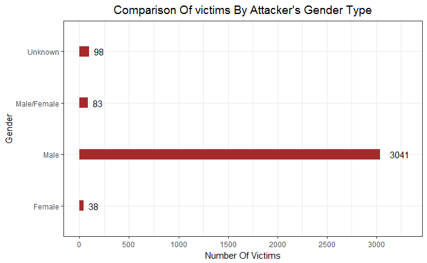

```r
ggplot(shootings,aes(x=Gender,y=Total.victims))+
  geom_bar(stat="summary",fun.y=sum,fill="#A52A2A",width=0.2)+
  stat_summary(aes(label=..y..), fun.y=sum, geom="text",hjust = -0.5)+
  labs(x="Gender",y="Number Of Victims",title = "Comparison Of victims By Attacker's Gender Type")+
  scale_y_continuous(limits = c(0,3300),breaks = seq(0,3300,500))+
  theme_bw()+
  coord_flip()+
  theme(plot.title = element_text(hjust = 0.5,size = 14))+
  ggsave(filename = "outputs/fig-9.png",width = 6,height = 5)
```

## 9. Province Based Exploration

```r
shootings$Province <- ""
value <- ","
for(i in 1:nrow(shootings)){
 shootings[i,15] <-ifelse(shootings[i,3] != "",strsplit(shootings[i,3],",")[[1]][2],"")
}
```

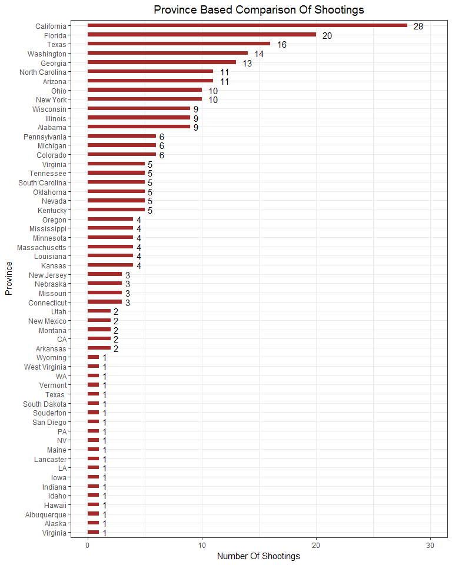

```r
shootings$Province <- ordered(shootings$Province,levels = names(sort(table(shootings$Province))))
ggplot(subset(shootings,Province != ""),aes(Province))+
  geom_bar(width = 0.4,fill="#A52A2A")+
  geom_text(stat='count',aes(label=..count..),hjust=-0.7)+
  scale_y_continuous(limits = c(0,30),breaks = seq(0,30,10))+
  labs(x="Province",y="Number Of Shootings",title = "Province Based Comparison Of Shootings")+
  coord_flip()+
  theme_bw()+
  theme(plot.title = element_text(hjust = 0.5,size = 14))+
  ggsave(filename = "outputs/fig-10.png",width = 8,height = 10)
```

- The Provice based comparison shows that most number of attacks were carried out in calfornia state. Now lets compare the provinces based number of victims.

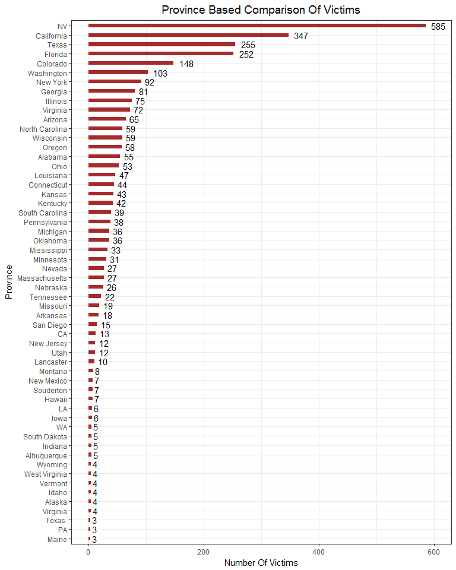

```r
victims_by_province <- subset(shootings,Province != "") %>%
  group_by(Province) %>%
  summarise(total=sum(Total.victims),n = n())%>%
  arrange(desc(total))
ggplot(victims_by_province,aes(x=reorder(Province,total),y=total))+
  geom_bar(stat="identity",width = 0.4,fill="#A52A2A")+
  geom_text(aes(label=total,hjust=-0.4))+
  labs(x="Province",y="Number Of Victims",title = "Province Based Comparison Of Victims")+
  scale_y_continuous(limits = c(0,600))+
  coord_flip()+
  theme_bw()+
  theme(plot.title = element_text(hjust = 0.5,size = 14))+
  ggsave(filename = "outputs/fig-11.png",width = 8,height = 10)
```

- The provine based comparison of victims show that most effected state is Naveda. Naveda reported high number of victims because it recenctly witnesed a mass shooting which was one of the most horrible attack’s in USA’s history. If we exclude that attack then most number of victims and attacks were reported by the state of California.

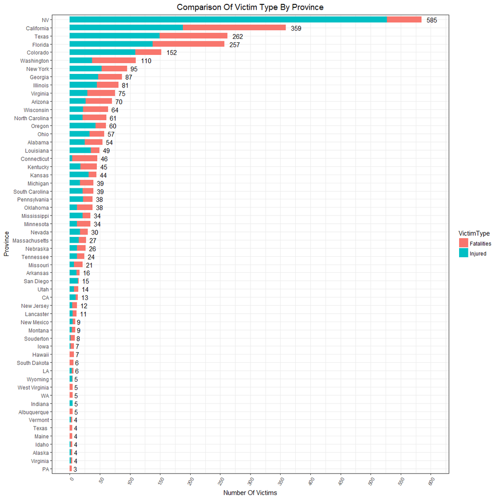

```r
long_data_province <- gather(subset(shootings,select = c(Province,Fatalities,Injured)),VictimType,NoOfVictims,Fatalities,Injured) %>%
  group_by(Province,VictimType) %>%
  summarize(total = sum(NoOfVictims))
#long_data_province
ggplot(subset(long_data_province,Province != ""),aes(x=reorder(Province,total),y=total))+
  geom_bar(stat = "summary",fun.y=sum,aes(y=total,fill=VictimType),width = 0.7)+
  stat_summary(geom ="text",aes(label=..y..),fun.y=sum,hjust = -0.5)+
  scale_y_continuous(breaks = seq(0,600,50),limits = c(0,600))+
  labs(x="Province",y="Number Of Victims",title="Comparison Of Victim Type By Province")+
  theme_bw()+
  coord_flip()+
  theme(axis.text.x = element_text(angle = 60, hjust = 1))+
  theme(plot.title = element_text(hjust = 0.5,size = 14))+
  ggsave(filename = "outputs/fig-12.png",width = 12,height = 12)
```

## 10. Race Based Exploration

```r
table(shootings$Race)
```

```
                                                                                                  Asian
                                                  2                                                   6
                                     Asian American                      Asian American/Some other race
                                                 11                                                   1
                                              black                                               Black
                                                  3                                                   4
                 Black American or African American          Black American or African American/Unknown
                                                 76                                                   1
                                             Latino                    Native American or Alaska Native
                                                  5                                                   3
                                              Other                                     Some other race
                                                  2                                                  20
                                  Two or more races                                             Unknown
                                                  2                                                  42
                                              white                                               White
                                                 12                                                   7
                White American or European American White American or European American/Some other Race
                                                122                                                   1
```

- The Race data column seems to have some duplicate values.Lets eliminate these duplicate values, so that column represents consistent values.

```r
shootings$Race <- ifelse(shootings$Race == "white","White",ifelse(shootings$Race == "black","Black",ifelse(shootings$Race == "" | shootings$Race == "Some other race" | shootings$Race == "Unknown", "Other",shootings$Race)))
table(shootings$Race)
```

```
                                              Asian                                      Asian American
                                                  6                                                  11
                     Asian American/Some other race                                               Black
                                                  1                                                   7
                 Black American or African American          Black American or African American/Unknown
                                                 76                                                   1
                                             Latino                    Native American or Alaska Native
                                                  5                                                   3
                                              Other                                   Two or more races
                                                 66                                                   2
                                              White                 White American or European American
                                                 19                                                 122
White American or European American/Some other Race
                                                  1
```

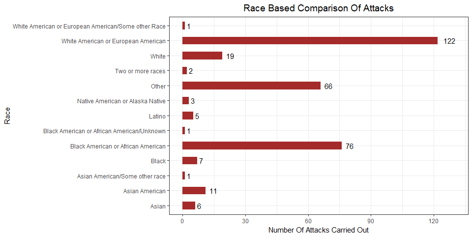

```r
ggplot(shootings,aes(x=Race))+
  geom_bar(fill="#A52A2A",width = 0.5)+
  geom_text(stat = "count",aes(label=..count..),hjust = -0.5)+
  labs(x="Race",y="Number Of Attacks Carried Out",title = "Race Based Comparison Of Attacks")+
  scale_y_continuous(limits=c(0,130),breaks = seq(0,130,30))+
  theme_bw()+
  coord_flip()+
  theme(plot.title = element_text(hjust = 0.5,size = 14))+
  ggsave(filename = "outputs/fig-13.png",width = 8,height = 5)
```

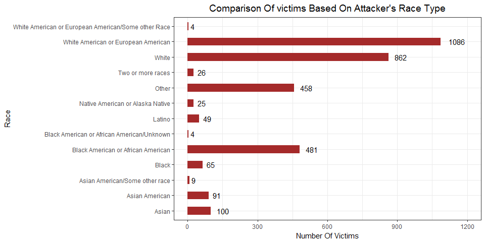

```r
ggplot(shootings,aes(x=Race,y=Total.victims))+
  geom_bar(stat="summary",fun.y=sum,fill="#A52A2A",width=0.5)+
  stat_summary(aes(label=..y..), fun.y=sum, geom="text",hjust = -0.5)+
  labs(x="Race",y="Number Of Victims",title = "Comparison Of victims Based On Attacker's Race Type")+
  scale_y_continuous(limits = c(0,1200),breaks = seq(0,1200,300))+
  theme_bw()+
  coord_flip()+
  theme(plot.title = element_text(hjust = 0.5,size = 14))+
  ggsave(filename = "outputs/fig-14.png",width = 9,height = 5)
```

## 11. Gender Based Analysis Of Shootings Over Year Timeline

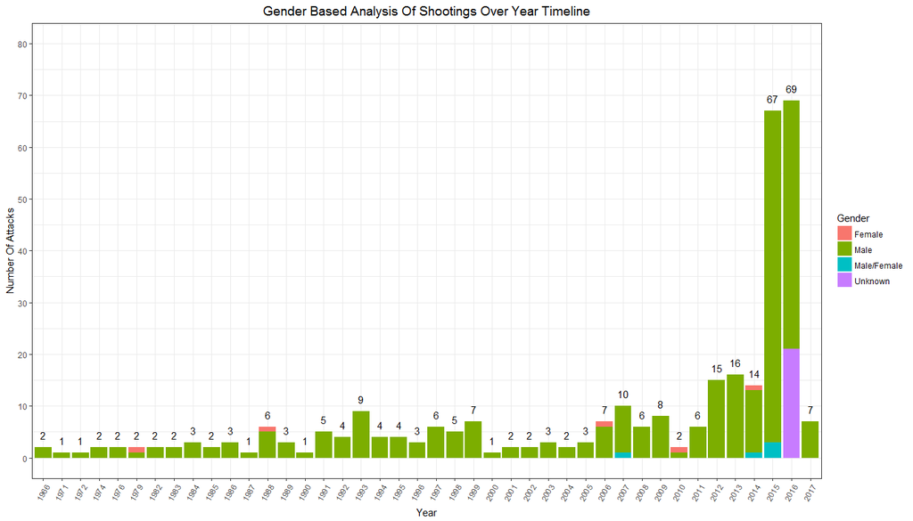

```r
ggplot(shootings,aes(x=Year))+
  geom_bar(aes(fill=Gender))+
  geom_text(stat='count',aes(label=..count..),vjust=-1)+
  scale_y_continuous(breaks = seq(0,80,10),limits = c(0,80))+
  labs(x="Year",y="Number Of Attacks",title="Gender Based Analysis Of Shootings Over Year Timeline")+
  theme_bw()+
  theme(axis.text.x = element_text(angle = 60, hjust = 1))+
  theme(plot.title = element_text(hjust = 0.5,size = 14))+
  ggsave(filename = "outputs/fig-15.png",width = 14,height = 5)
```

## 12. (Mental Health) Based Analysis Of Shootings Over Year Timeline

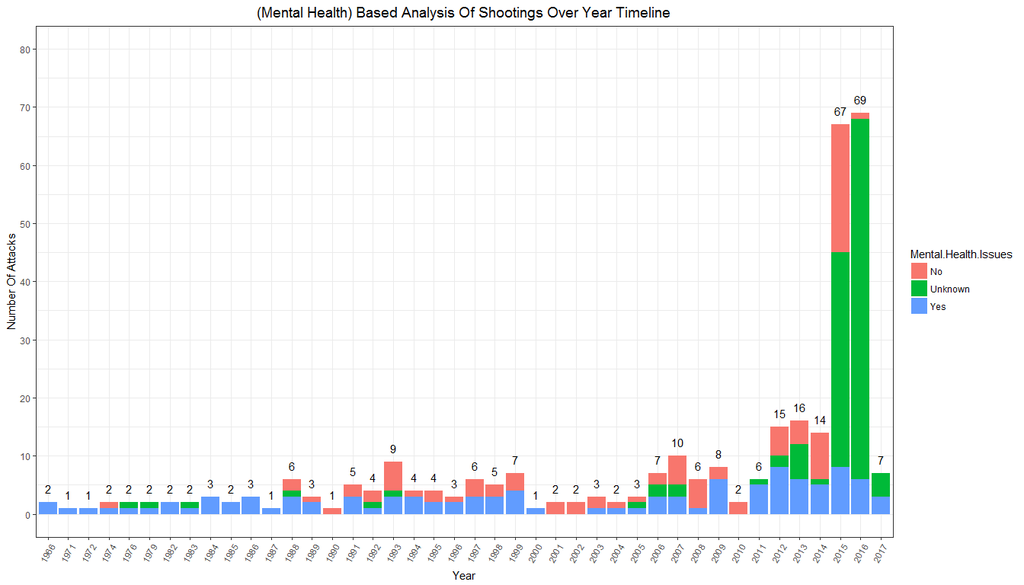

```r
ggplot(shootings,aes(x=Year))+
  geom_bar(aes(fill=Mental.Health.Issues))+
  geom_text(stat='count',aes(label=..count..),vjust=-1)+
  scale_y_continuous(breaks = seq(0,80,10),limits = c(0,80))+
  labs(x="Year",y="Number Of Attacks",title="(Mental Health) Based Analysis Of Shootings Over Year Timeline")+
  theme_bw()+
  theme(axis.text.x = element_text(angle = 60, hjust = 1))+
  theme(plot.title = element_text(hjust = 0.5,size = 14))+
  ggsave(filename = "outputs/fig-16.png",width = 14,height = 5)
```

## 13. Race Based Analysis Of Shootings Over Year Timeline

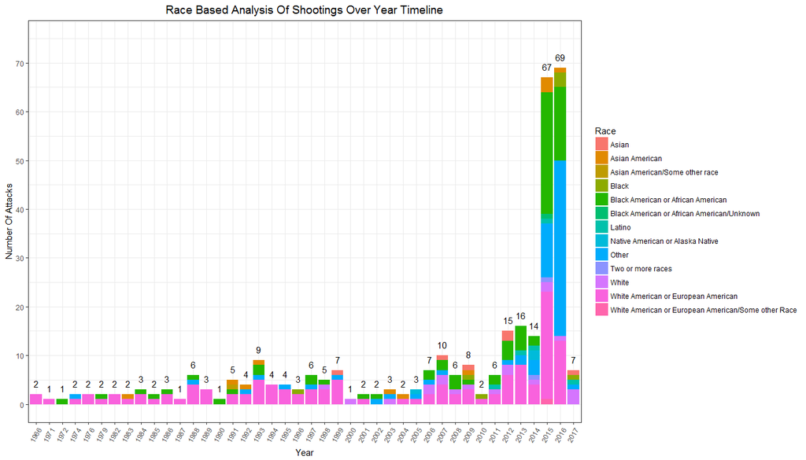

```r
ggplot(shootings,aes(x=Year))+
  geom_bar(aes(fill=Race))+
  geom_text(stat='count',aes(label=..count..),vjust=-1)+
  scale_y_continuous(breaks = seq(0,75,10),limits = c(0,75))+
  labs(x="Year",y="Number Of Attacks",title="Race Based Analysis Of Shootings Over Year Timeline")+
  theme_bw()+
  theme(axis.text.x = element_text(angle = 60, hjust = 1))+
  theme(plot.title = element_text(hjust = 0.5,size = 14))+
  ggsave(filename = "outputs/fig-17.png",width = 14,height = 5)
```